# 5.2 Enriched pTAI GO analysis

# Gene Ontology (GO) enrichment

## Top 100 TAI genes

Based on the top 100 contributors to TAI, we can assess whether certain GO categories are enriched. We use `Fisher’s exact` test statistics with the `parent-child algorithm` as implemented in `TopGO`. [Note, the enrichment analysis per se was not possible but the GO terms on each gene was analysed]

```r
# library(ggfortify)
library(tximport)
library(myTAI)
# library(topGO)
library(tidyverse)
```

## Load data

### Load intersections

```r
# Ec_PES_32m_unicell <- readr::read_csv("data/pTAI/Ec_PES_32m_unicell.csv")
# Ec_PES_25f_unicell <- readr::read_csv("data/pTAI/Ec_PES_25f_unicell.csv")
Ec_PES_32m.sqrt_unicell <- readr::read_csv("data/pTAI/Ec_PES_32m.sqrt_unicell.csv")
Ec_PES_25f.sqrt_unicell <- readr::read_csv("data/pTAI/Ec_PES_25f.sqrt_unicell.csv")
# Ec_PES_32m.log2_unicell <- readr::read_csv("data/pTAI/Ec_PES_32m.log2_unicell.csv")
# Ec_PES_25f.log2_unicell <- readr::read_csv("data/pTAI/Ec_PES_25f.log2_unicell.csv")
# Ec_PES_32m.rank_unicell <- readr::read_csv("data/pTAI/Ec_PES_32m.rank_unicell.csv")
# Ec_PES_25f.rank_unicell <- readr::read_csv("data/pTAI/Ec_PES_25f.rank_unicell.csv")
# Ec_PES_32m.rlog_unicell <- readr::read_csv("data/pTAI/Ec_PES_32m.rlog_unicell.csv")
# Ec_PES_25f.rlog_unicell <- readr::read_csv("data/pTAI/Ec_PES_25f.rlog_unicell.csv")
Ec_PES_32m.sqrt_multicell <- readr::read_csv("data/pTAI/Ec_PES_32m.sqrt_multicell.csv")
Ec_PES_25f.sqrt_multicell <- readr::read_csv("data/pTAI/Ec_PES_25f.sqrt_multicell.csv")
# Ec_PES_32m_denoised_unicell <- readr::read_csv("data/pTAI/Ec_PES_32m_denoised_unicell.csv")
# Ec_PES_25f_denoised_unicell <- readr::read_csv("data/pTAI/Ec_PES_25f_denoised_unicell.csv")
# Ec_PES_32m.sqrt_denoised_unicell <- readr::read_csv("data/pTAI/Ec_PES_32m.sqrt_denoised_unicell.csv")
# Ec_PES_25f.sqrt_denoised_unicell <- readr::read_csv("data/pTAI/Ec_PES_25f.sqrt_denoised_unicell.csv")
# Ec_PES_32m.log2_denoised_unicell <- readr::read_csv("data/pTAI/Ec_PES_32m.log2_denoised_unicell.csv")
# Ec_PES_25f.log2_denoised_unicell <- readr::read_csv("data/pTAI/Ec_PES_25f.log2_denoised_unicell.csv")
```

### Load PES

```r
# # Non-transformed
Ec_PES_32m <-
  readr::read_csv(file = "data/Ec_PES_32m.csv")
Ec_PES_25f <-
  readr::read_csv(file = "data/Ec_PES_25f.csv")
# sqrt-tranformed
Ec_PES_32m.sqrt <-
  readr::read_csv(file = "data/Ec_PES_32m.sqrt.csv")
Ec_PES_25f.sqrt <-
  readr::read_csv(file = "data/Ec_PES_25f.sqrt.csv")
# # log2-tranformed
# Ec_PES_32m.log2 <-
#   readr::read_csv(file = "data/Ec_PES_32m.log2.csv")
# Ec_PES_25f.log2 <-
#   readr::read_csv(file = "data/Ec_PES_25f.log2.csv")
#
# # rank-tranformed
# Ec_PES_32m.rank <-
#   readr::read_csv(file = "data/Ec_PES_32m.rank.csv")
# Ec_PES_25f.rank <-
#   readr::read_csv(file = "data/Ec_PES_25f.rank.csv")
#
# # rlog-tranformed
# Ec_PES_32m.rlog <-
#   readr::read_csv(file = "data/Ec_PES_32m.rlog.csv")
# Ec_PES_25f.rlog <-
#   readr::read_csv(file = "data/Ec_PES_25f.rlog.csv")
```

```r
# Fs_LRT.1000 <-
#   readr::read_csv("data/Fs_LRT_1000.csv")
# Fd_LRT.1000 <-
#   readr::read_csv("data/Fd_LRT_1000.csv")
```

```r
# similar to unicellular_pMat() from 2_4_unicell_pTAI.Rmd
process_pMat <- function(PES, dropzero = F, ordered_stages, top_genes = F, n_genes = 500, stage_select = "gamete"){

        if(!is.data.frame(PES))
                stop("PES is not a dataframe")

        stage_select <- rlang::sym(stage_select)

        PES_filt <- PES

        PES_filt <- PES_filt %>%
                myTAI::pMatrix() %>%
                tibble::as_tibble(rownames = "GeneID")

        # in case one wants to select the top N genes.
        if(top_genes){
                PES_filt <- PES_filt %>%
                        dplyr::slice_max({{stage_select}}, n = n_genes)
        }

        PES_filt <- PES_filt %>%
                tidyr::pivot_longer(!GeneID, names_to = "Stage", values_to = "pTAI")

        # make factor
        PES_filt$Stage <- base::factor(PES_filt$Stage, ordered_stages)
        return(PES_filt)
}
```

### Load interproscan data

```r
GO_Ec <- read_delim("data/Interproscan/Ec_ips/Ectocarpus-sp7.filt.processed.faa.tsv",
                    delim = "\t", col_select = c(1,14)) %>%
        drop_na() %>%
        filter(GO_term != "-") %>%
        separate_rows(GO_term, sep = "\\|") %>%
        # dplyr::mutate(GeneID = str_remove(GeneID, "\\.[^.]+$")) %>%
        arrange(GeneID) %>%
        distinct()
IPR_Ec <- read_delim("data/Interproscan/Ec_ips/Ectocarpus-sp7.filt.processed.faa.tsv",
                    delim = "\t") %>%
        dplyr::select(GeneID, Analysis, Signature_description, GO_term) %>%
        # dplyr::mutate(GeneID = str_remove(GeneID, "\\.[^.]+$")) %>%
        arrange(GeneID) %>%
        distinct()
length(unique(GO_Ec$GO_term))
length(unique(GO_Ec$GeneID))
```

There are 18,289 GO terms (whereof 2070 are unique) attached to 9881 genes (including isoforms) in *Ectocarpus*.

# GO×Top100pTAI analysis

## Ectocarpus

### raw TPM

```r
# GO_Ec %>% dplyr::filter(GeneID %in% Ec_PES_32m_unicell$GeneID)
# Ec_PES_32m %>% dplyr::filter(GeneID %in% Ec_PES_32m_unicell$GeneID) %>% dplyr::select(Phylostratum, GeneID)
# IPR_Ec %>% dplyr::filter(GeneID %in% Ec_PES_32m_unicell$GeneID)
#
# GO_Ec %>% dplyr::filter(GeneID %in% Ec_PES_25f_unicell$GeneID)
# Ec_PES_25f %>% dplyr::filter(GeneID %in% Ec_PES_25f_unicell$GeneID) %>% dplyr::select(Phylostratum, GeneID)
# IPR_Ec %>% dplyr::filter(GeneID %in% Ec_PES_25f_unicell$GeneID)
```

Male: - GO:0009765 (photosynthesis, light harvesting) - GO:0016020 (membrane) - GO:0046872 (metal ion binding) - GO:0071203 (WASH complex) - GO:0016813 (hydrolase activity, acting on carbon-nitrogen (but not peptide) bonds, in linear amidines)

Female: - GO:0046872 (metal ion binding) - GO:0071203 (WASH complex) - GO:0016813 (hydrolase activity, acting on carbon-nitrogen (but not peptide) bonds, in linear amidines)

### sqrt-transform

```r
GO_Ec %>% dplyr::filter(GeneID %in% Ec_PES_32m.sqrt_unicell$GeneID)
```

| GeneID | GO_term |
| --- | --- |
| Ec-05_006030.2 | GO:0003676 |
| Ec-05_006030.2 | GO:0008270 |
| Ec-07_001470.1 | GO:0009765 |
| Ec-07_001470.1 | GO:0016020 |
| Ec-07_003720.1 | GO:0005515 |
| Ec-07_004620.1 | GO:0005515 |
| Ec-07_007750.1 | GO:0051260 |
| Ec-15_001030.1 | GO:0009765 |
| Ec-15_001030.1 | GO:0016020 |
| Ec-19_001850.1 | GO:0016620 |

[output cut: 8 more lines]

```r
Ec_PES_32m %>% dplyr::filter(GeneID %in% Ec_PES_32m.sqrt_unicell$GeneID) %>% dplyr::select(PS, GeneID)
```

| PS | GeneID |
| --- | --- |
| 7 | Ec-00_001290.1 |
| 11 | Ec-00_006310.1 |
| 11 | Ec-00_010730.1 |
| 11 | Ec-00_010970.1 |
| 7 | Ec-01_002470.1 |
| 7 | Ec-01_002550.1 |
| 6 | Ec-01_003340.1 |
| 11 | Ec-01_004010.2 |
| 11 | Ec-01_009530.2 |
| 4 | Ec-01_010920.1 |

[output cut: 105 more lines]

```r
IPR_Ec %>% dplyr::filter(GeneID %in% Ec_PES_32m.sqrt_unicell$GeneID)
```

| GeneID | Analysis | Signature_description | GO_term |
| --- | --- | --- | --- |
| Ec-00_001290.1 | Coils | Coil | NA |
| Ec-00_001290.1 | MobiDBLite | consensus disorder prediction | NA |
| Ec-00_006310.1 | MobiDBLite | consensus disorder prediction | NA |
| Ec-01_002550.1 | Coils | Coil | NA |
| Ec-01_002550.1 | ProSiteProfiles | Prokaryotic membrane lipoprotein lipid attachment site profile. | NA |
| Ec-01_010920.1 | Gene3D | - | - |
| Ec-01_010920.1 | SUPERFAMILY | Bet v1-like | NA |
| Ec-01_010920.1 | Coils | Coil | NA |
| Ec-01_011760.1 | Coils | Coil | NA |
| Ec-02_003400.1 | MobiDBLite | consensus disorder prediction | NA |

[output cut: 147 more lines]

```r
GO_Ec %>% dplyr::filter(GeneID %in% Ec_PES_25f.sqrt_unicell$GeneID)
```

| GeneID | GO_term |
| --- | --- |
| Ec-05_006030.2 | GO:0003676 |
| Ec-05_006030.2 | GO:0008270 |
| Ec-06_004470.1 | GO:0005515 |
| Ec-19_001850.1 | GO:0016620 |
| Ec-19_001850.1 | GO:0051287 |
| Ec-19_001850.1 | GO:0006006 |
| Ec-19_001850.1 | GO:0050661 |
| Ec-20_001230.1 | GO:0046872 |
| Ec-21_005870.1 | GO:0071203 |
| Ec-22_003700.1 | GO:0016813 |

[output cut: 1 more lines]

```r
Ec_PES_25f %>% dplyr::filter(GeneID %in% Ec_PES_25f.sqrt_unicell$GeneID) %>% dplyr::select(PS, GeneID)
```

| PS | GeneID |
| --- | --- |
| 7 | Ec-00_001290.1 |
| 11 | Ec-00_006310.1 |
| 7 | Ec-00_008660.1 |
| 11 | Ec-00_010730.1 |
| 11 | Ec-00_010970.1 |
| 7 | Ec-01_001100.1 |
| 7 | Ec-01_002470.1 |
| 7 | Ec-01_002550.1 |
| 6 | Ec-01_003340.1 |
| 11 | Ec-01_004010.2 |

[output cut: 88 more lines]

```r
IPR_Ec %>% dplyr::filter(GeneID %in% Ec_PES_25f.sqrt_unicell$GeneID)
```

| GeneID | Analysis | Signature_description | GO_term |
| --- | --- | --- | --- |
| Ec-00_001290.1 | Coils | Coil | NA |
| Ec-00_001290.1 | MobiDBLite | consensus disorder prediction | NA |
| Ec-00_006310.1 | MobiDBLite | consensus disorder prediction | NA |
| Ec-00_008660.1 | MobiDBLite | consensus disorder prediction | NA |
| Ec-01_001100.1 | Coils | Coil | NA |
| Ec-01_001100.1 | MobiDBLite | consensus disorder prediction | NA |
| Ec-01_002550.1 | Coils | Coil | NA |
| Ec-01_002550.1 | ProSiteProfiles | Prokaryotic membrane lipoprotein lipid attachment site profile. | NA |
| Ec-01_010920.1 | Gene3D | - | - |
| Ec-01_010920.1 | SUPERFAMILY | Bet v1-like | NA |

[output cut: 101 more lines]

metal ion binding (GO:0046872)

### log2-transform

```r
# GO_Ec %>% dplyr::filter(GeneID %in% Ec_PES_32m.log2_unicell$GeneID)
# Ec_PES_32m %>% dplyr::filter(GeneID %in% Ec_PES_32m.log2_unicell$GeneID) %>% dplyr::select(Phylostratum, GeneID)
# IPR_Ec %>% dplyr::filter(GeneID %in% Ec_PES_32m.log2_unicell$GeneID)
#
# GO_Ec %>% dplyr::filter(GeneID %in% Ec_PES_25f.log2_unicell$GeneID)
# Ec_PES_25f %>% dplyr::filter(GeneID %in% Ec_PES_25f.log2_unicell$GeneID) %>% dplyr::select(Phylostratum, GeneID)
# IPR_Ec %>% dplyr::filter(GeneID %in% Ec_PES_25f.log2_unicell$GeneID)
```

### rank-transform

```r
# GO_Ec %>% dplyr::filter(GeneID %in% Ec_PES_32m.rank_unicell$GeneID)
# Ec_PES_32m %>% dplyr::filter(GeneID %in% Ec_PES_32m.rank_unicell$GeneID) %>% dplyr::select(Phylostratum, GeneID)
# IPR_Ec %>% dplyr::filter(GeneID %in% Ec_PES_32m.rank_unicell$GeneID)
#
# GO_Ec %>% dplyr::filter(GeneID %in% Ec_PES_25f.rank_unicell$GeneID)
# Ec_PES_25f %>% dplyr::filter(GeneID %in% Ec_PES_25f.rank_unicell$GeneID) %>% dplyr::select(Phylostratum, GeneID)
# IPR_Ec %>% dplyr::filter(GeneID %in% Ec_PES_25f.rank_unicell$GeneID)
```

With the rank transform, we are screening essentially the most recent PS only.

### rlog-transform

```r
# GO_Ec %>% dplyr::filter(GeneID %in% Ec_PES_32m.rlog_unicell$GeneID)
# Ec_PES_32m %>% dplyr::filter(GeneID %in% Ec_PES_32m.rlog_unicell$GeneID) %>% dplyr::select(Phylostratum, GeneID)
# IPR_Ec %>% dplyr::filter(GeneID %in% Ec_PES_32m.rlog_unicell$GeneID)
#
# GO_Ec %>% dplyr::filter(GeneID %in% Ec_PES_25f.rlog_unicell$GeneID)
# Ec_PES_25f %>% dplyr::filter(GeneID %in% Ec_PES_25f.rlog_unicell$GeneID) %>% dplyr::select(Phylostratum, GeneID)
# IPR_Ec %>% dplyr::filter(GeneID %in% Ec_PES_25f.rlog_unicell$GeneID)
```

metal ion binding (GO:0046872)

## What is the proportion of genes without GO terms?

### sqrt TPM

```r
# sqrt males
pTAI100 <- Ec_PES_32m.sqrt_unicell %>%
        dplyr::mutate(pTAI100 = 1)

GO_fisher_input <- Ec_PES_32m.sqrt %>%
        dplyr::select(GeneID) %>%
        dplyr::left_join(GO_Ec, by = join_by(GeneID)) %>%
        dplyr::mutate(GO_present = case_when(
                !is.na(GO_term) ~ "GO_present",
                TRUE ~ "GO_notpresent"
                )) %>%
        dplyr::left_join(pTAI100, by = join_by(GeneID)) %>%
        dplyr::mutate(pTAI100 = case_when(
                pTAI100 == 1 ~ "top TAI contributors",
                TRUE ~ "not top TAI contributors"
                )) %>%
        dplyr::select(-GO_term) %>%
        dplyr::distinct()
fisher.test(GO_fisher_input$pTAI100, GO_fisher_input$GO_present, alternative = "less")
```

```
##
##  Fisher's Exact Test for Count Data
##
## data:  GO_fisher_input$pTAI100 and GO_fisher_input$GO_present
## p-value < 2.2e-16
## alternative hypothesis: true odds ratio is less than 1
## 95 percent confidence interval:
##  0.000000 0.171571
## sample estimates:
## odds ratio
##   0.100071
```

```r
# sqrt females
pTAI100 <- Ec_PES_25f.sqrt_unicell %>%
        dplyr::mutate(pTAI100 = 1)

GO_fisher_input <- Ec_PES_25f.sqrt %>%
        dplyr::select(GeneID) %>%
        dplyr::left_join(GO_Ec, by = join_by(GeneID)) %>%
        dplyr::mutate(GO_present = case_when(
                !is.na(GO_term) ~ "GO_present",
                TRUE ~ "GO_notpresent"
                )) %>%
        dplyr::left_join(pTAI100, by = join_by(GeneID)) %>%
        dplyr::mutate(pTAI100 = case_when(
                pTAI100 == 1 ~ "top TAI contributors",
                TRUE ~ "not top TAI contributors"
                )) %>%
        dplyr::select(-GO_term) %>%
        dplyr::distinct()
fisher.test(GO_fisher_input$pTAI100, GO_fisher_input$GO_present, alternative = "less")
```

```
##
##  Fisher's Exact Test for Count Data
##
## data:  GO_fisher_input$pTAI100 and GO_fisher_input$GO_present
## p-value < 2.2e-16
## alternative hypothesis: true odds ratio is less than 1
## 95 percent confidence interval:
##  0.0000000 0.1259462
## sample estimates:
## odds ratio
## 0.06177139
```

There is significant enrichment for genes **without** GO annotations.

We now plot the results.

### sqrt TPM

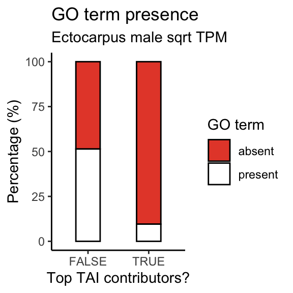

```r
# sqrt males

pTAI100 <- Ec_PES_32m.sqrt_unicell %>%
        dplyr::mutate(pTAI100 = 1)

GO_plot_input <- Ec_PES_32m.sqrt %>%
        dplyr::select(GeneID) %>%
        dplyr::left_join(GO_Ec, by = join_by(GeneID)) %>%
        dplyr::mutate(GO_present = case_when(
                !is.na(GO_term) ~ "present",
                TRUE ~ "absent"
                )) %>%
        dplyr::left_join(pTAI100, by = join_by(GeneID)) %>%
        dplyr::mutate(pTAI100 = case_when(
                pTAI100 == 1 ~ T,
                TRUE ~ F
                )) %>%
        dplyr::select(-GO_term) %>%
        dplyr::distinct()

GO_plot_input %>%
        dplyr::group_by(pTAI100, GO_present) %>%
        dplyr::summarise(count = n()) %>%
        dplyr::group_by(pTAI100) %>%
        dplyr::mutate(perc = count/sum(count)) %>%
        ggplot2::ggplot(aes(x = pTAI100, y = perc*100, fill = GO_present)) +
        ggplot2::geom_col(colour = "black", width = 0.4) +
        ggplot2::scale_fill_manual(values = c("#E64B35FF", "white")) +
        ggplot2::theme_classic() +
        ggplot2::labs(title = "GO term presence",
                      subtitle = "Ectocarpus male sqrt TPM",
                      fill = "GO term",
                      x = "Top TAI contributors?",
                      y = "Percentage (%)")
```

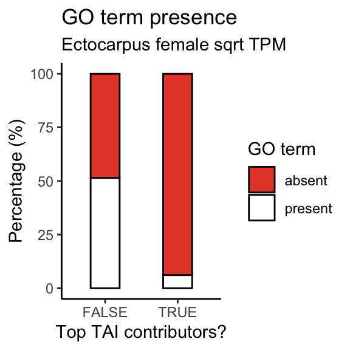

```
unicellular: 9.57% in males with GO terms
unicellular: 6.12% in females with GO terms
```

```r
# sqrt females

pTAI100 <- Ec_PES_25f.sqrt_unicell %>%
        dplyr::mutate(pTAI100 = 1)

GO_plot_input <- Ec_PES_25f.sqrt %>%
        dplyr::select(GeneID) %>%
        dplyr::left_join(GO_Ec, by = join_by(GeneID)) %>%
        dplyr::mutate(GO_present = case_when(
                !is.na(GO_term) ~ "present",
                TRUE ~ "absent"
                )) %>%
        dplyr::left_join(pTAI100, by = join_by(GeneID)) %>%
        dplyr::mutate(pTAI100 = case_when(
                pTAI100 == 1 ~ T,
                TRUE ~ F
                )) %>%
        dplyr::select(-GO_term) %>%
        dplyr::distinct()

GO_plot_input %>%
        dplyr::group_by(pTAI100, GO_present) %>%
        dplyr::summarise(count = n()) %>%
        dplyr::group_by(pTAI100) %>%
        dplyr::mutate(perc = count/sum(count)) %>%
        ggplot2::ggplot(aes(x = pTAI100, y = perc*100, fill = GO_present)) +
        ggplot2::geom_col(colour = "black", width = 0.4) +
        ggplot2::scale_fill_manual(values = c("#E64B35FF", "white")) +
        ggplot2::theme_classic() +
        ggplot2::labs(title = "GO term presence",
                      subtitle = "Ectocarpus female sqrt TPM",
                      fill = "GO term",
                      x = "Top TAI contributors?",
                      y = "Percentage (%)")
```

### sqrt TPM [multicellular]

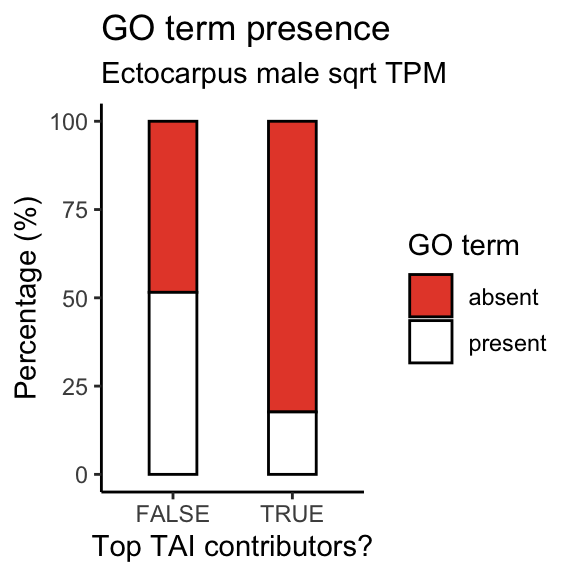

```r
# sqrt males

pTAI100 <- Ec_PES_32m.sqrt_multicell %>%
        dplyr::mutate(pTAI100 = 1)

GO_plot_input <- Ec_PES_32m.sqrt %>%
        dplyr::select(GeneID) %>%
        dplyr::left_join(GO_Ec, by = join_by(GeneID)) %>%
        dplyr::mutate(GO_present = case_when(
                !is.na(GO_term) ~ "present",
                TRUE ~ "absent"
                )) %>%
        dplyr::left_join(pTAI100, by = join_by(GeneID)) %>%
        dplyr::mutate(pTAI100 = case_when(
                pTAI100 == 1 ~ T,
                TRUE ~ F
                )) %>%
        dplyr::select(-GO_term) %>%
        dplyr::distinct()

GO_plot_input %>%
        dplyr::group_by(pTAI100, GO_present) %>%
        dplyr::summarise(count = n()) %>%
        dplyr::group_by(pTAI100) %>%
        dplyr::mutate(perc = count/sum(count)) %>%
        ggplot2::ggplot(aes(x = pTAI100, y = perc*100, fill = GO_present)) +
        ggplot2::geom_col(colour = "black", width = 0.4) +
        ggplot2::scale_fill_manual(values = c("#E64B35FF", "white")) +
        ggplot2::theme_classic() +
        ggplot2::labs(title = "GO term presence",
                      subtitle = "Ectocarpus male sqrt TPM",
                      fill = "GO term",
                      x = "Top TAI contributors?",
                      y = "Percentage (%)")
```

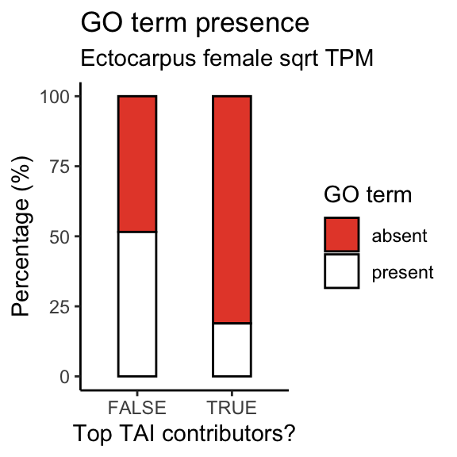

```
multicellular: 17.7% in males with GO terms
multicellular: 18.9% in females with GO terms
```

```r
# sqrt females

pTAI100 <- Ec_PES_25f.sqrt_multicell %>%
        dplyr::mutate(pTAI100 = 1)

GO_plot_input <- Ec_PES_25f.sqrt %>%
        dplyr::select(GeneID) %>%
        dplyr::left_join(GO_Ec, by = join_by(GeneID)) %>%
        dplyr::mutate(GO_present = case_when(
                !is.na(GO_term) ~ "present",
                TRUE ~ "absent"
                )) %>%
        dplyr::left_join(pTAI100, by = join_by(GeneID)) %>%
        dplyr::mutate(pTAI100 = case_when(
                pTAI100 == 1 ~ T,
                TRUE ~ F
                )) %>%
        dplyr::select(-GO_term) %>%
        dplyr::distinct()

GO_plot_input %>%
        dplyr::group_by(pTAI100, GO_present) %>%
        dplyr::summarise(count = n()) %>%
        dplyr::group_by(pTAI100) %>%
        dplyr::mutate(perc = count/sum(count)) %>%
        ggplot2::ggplot(aes(x = pTAI100, y = perc*100, fill = GO_present)) +
        ggplot2::geom_col(colour = "black", width = 0.4) +
        ggplot2::scale_fill_manual(values = c("#E64B35FF", "white")) +
        ggplot2::theme_classic() +
        ggplot2::labs(title = "GO term presence",
                      subtitle = "Ectocarpus female sqrt TPM",
                      fill = "GO term",
                      x = "Top TAI contributors?",
                      y = "Percentage (%)")
```

## What is the proportion of genes without interproscan results?

### sqrt TPM

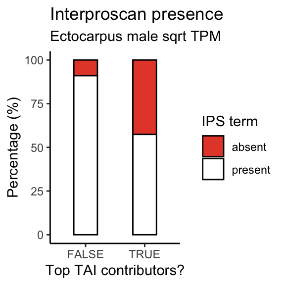

```r
# sqrt males

pTAI100 <- Ec_PES_32m.sqrt_unicell %>%
        dplyr::mutate(pTAI100 = 1)

IPR_plot_input <- Ec_PES_32m.sqrt %>%
        dplyr::select(GeneID) %>%
        dplyr::left_join(IPR_Ec, by = join_by(GeneID)) %>%
        dplyr::mutate(IPR_present = case_when(
                !is.na(Analysis) ~ "present",
                TRUE ~ "absent"
                )) %>%
        dplyr::left_join(pTAI100, by = join_by(GeneID)) %>%
        dplyr::mutate(pTAI100 = case_when(
                pTAI100 == 1 ~ T,
                TRUE ~ F
                )) %>%
        dplyr::select(-c(GO_term, Analysis, Signature_description)) %>%
        dplyr::distinct()

IPR_plot_input %>%
        dplyr::group_by(pTAI100, IPR_present) %>%
        dplyr::summarise(count = n()) %>%
        dplyr::group_by(pTAI100) %>%
        dplyr::mutate(perc = count/sum(count)) %>%
        ggplot2::ggplot(aes(x = pTAI100, y = perc*100, fill = IPR_present)) +
        ggplot2::geom_col(colour = "black", width = 0.4) +
        ggplot2::scale_fill_manual(values = c("#E64B35FF", "white")) +
        ggplot2::theme_classic() +
        ggplot2::labs(title = "Interproscan presence",
                      subtitle = "Ectocarpus male sqrt TPM",
                      fill = "IPS term",
                      x = "Top TAI contributors?",
                      y = "Percentage (%)")
```

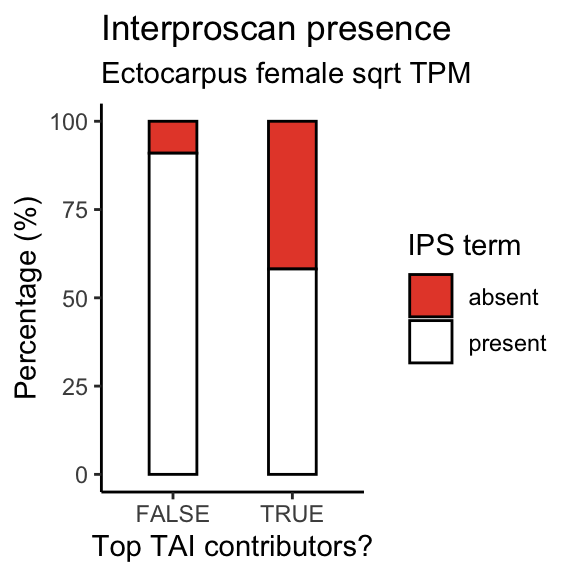

```
unicellular: 57.4% in males with IPR
unicellular: 58.2% in females with IPR
```

```r
# sqrt females

pTAI100 <- Ec_PES_25f.sqrt_unicell %>%
        dplyr::mutate(pTAI100 = 1)

IPR_plot_input <- Ec_PES_25f.sqrt %>%
        dplyr::select(GeneID) %>%
        dplyr::left_join(IPR_Ec, by = join_by(GeneID)) %>%
        dplyr::mutate(IPR_present = case_when(
                !is.na(Analysis) ~ "present",
                TRUE ~ "absent"
                )) %>%
        dplyr::left_join(pTAI100, by = join_by(GeneID)) %>%
        dplyr::mutate(pTAI100 = case_when(
                pTAI100 == 1 ~ T,
                TRUE ~ F
                )) %>%
        dplyr::select(-c(GO_term, Analysis, Signature_description)) %>%
        dplyr::distinct()

IPR_plot_input %>%
        dplyr::group_by(pTAI100, IPR_present) %>%
        dplyr::summarise(count = n()) %>%
        dplyr::group_by(pTAI100) %>%
        dplyr::mutate(perc = count/sum(count)) %>%
        ggplot2::ggplot(aes(x = pTAI100, y = perc*100, fill = IPR_present)) +
        ggplot2::geom_col(colour = "black", width = 0.4) +
        ggplot2::scale_fill_manual(values = c("#E64B35FF", "white")) +
        ggplot2::theme_classic() +
        ggplot2::labs(title = "Interproscan presence",
                      subtitle = "Ectocarpus female sqrt TPM",
                      fill = "IPS term",
                      x = "Top TAI contributors?",
                      y = "Percentage (%)")
```

### sqrt TPM [multicellular]

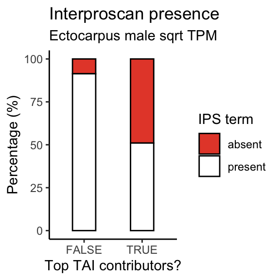

```r
# sqrt males

pTAI100 <- Ec_PES_32m.sqrt_multicell %>%
        dplyr::mutate(pTAI100 = 1)

IPR_plot_input <- Ec_PES_32m.sqrt %>%
        dplyr::select(GeneID) %>%
        dplyr::left_join(IPR_Ec, by = join_by(GeneID)) %>%
        dplyr::mutate(IPR_present = case_when(
                !is.na(Analysis) ~ "present",
                TRUE ~ "absent"
                )) %>%
        dplyr::left_join(pTAI100, by = join_by(GeneID)) %>%
        dplyr::mutate(pTAI100 = case_when(
                pTAI100 == 1 ~ T,
                TRUE ~ F
                )) %>%
        dplyr::select(-c(GO_term, Analysis, Signature_description)) %>%
        dplyr::distinct()

IPR_plot_input %>%
        dplyr::group_by(pTAI100, IPR_present) %>%
        dplyr::summarise(count = n()) %>%
        dplyr::group_by(pTAI100) %>%
        dplyr::mutate(perc = count/sum(count)) %>%
        ggplot2::ggplot(aes(x = pTAI100, y = perc*100, fill = IPR_present)) +
        ggplot2::geom_col(colour = "black", width = 0.4) +
        ggplot2::scale_fill_manual(values = c("#E64B35FF", "white")) +
        ggplot2::theme_classic() +
        ggplot2::labs(title = "Interproscan presence",
                      subtitle = "Ectocarpus male sqrt TPM",
                      fill = "IPS term",
                      x = "Top TAI contributors?",
                      y = "Percentage (%)")
```

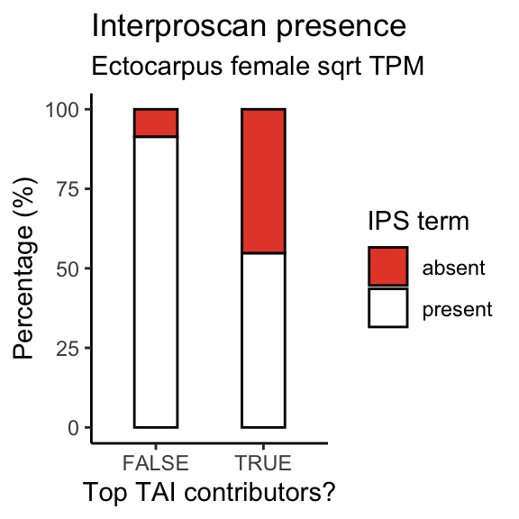

```
multicellular: 51.0% in males with IPR
multicellular: 54.7% in females with IPR
```

```r
# sqrt females

pTAI100 <- Ec_PES_25f.sqrt_multicell %>%
        dplyr::mutate(pTAI100 = 1)

IPR_plot_input <- Ec_PES_25f.sqrt %>%
        dplyr::select(GeneID) %>%
        dplyr::left_join(IPR_Ec, by = join_by(GeneID)) %>%
        dplyr::mutate(IPR_present = case_when(
                !is.na(Analysis) ~ "present",
                TRUE ~ "absent"
                )) %>%
        dplyr::left_join(pTAI100, by = join_by(GeneID)) %>%
        dplyr::mutate(pTAI100 = case_when(
                pTAI100 == 1 ~ T,
                TRUE ~ F
                )) %>%
        dplyr::select(-c(GO_term, Analysis, Signature_description)) %>%
        dplyr::distinct()

IPR_plot_input %>%
        dplyr::group_by(pTAI100, IPR_present) %>%
        dplyr::summarise(count = n()) %>%
        dplyr::group_by(pTAI100) %>%
        dplyr::mutate(perc = count/sum(count)) %>%
        ggplot2::ggplot(aes(x = pTAI100, y = perc*100, fill = IPR_present)) +
        ggplot2::geom_col(colour = "black", width = 0.4) +
        ggplot2::scale_fill_manual(values = c("#E64B35FF", "white")) +
        ggplot2::theme_classic() +
        ggplot2::labs(title = "Interproscan presence",
                      subtitle = "Ectocarpus female sqrt TPM",
                      fill = "IPS term",
                      x = "Top TAI contributors?",
                      y = "Percentage (%)")
```

In contrast to the GO terms, multicellular stages tend to have less IPR domain annotation.

## What is the proportion of genes with `consensus disorder prediction`?

```r
POI <- c("consensus disorder prediction") # property of interest

IPR_Ec_disorder <- IPR_Ec[IPR_Ec$Signature_description %in% POI, ] %>%
        dplyr::select(GeneID) %>%
        dplyr::distinct() %>%
        dplyr::mutate(POI = 1)
```

### sqrt TPM

```r
# sqrt males

pTAI100 <- Ec_PES_32m.sqrt_unicell %>%
        dplyr::mutate(pTAI100 = 1)

POI_fisher_input <- Ec_PES_32m.sqrt %>%
        dplyr::select(GeneID) %>%
        dplyr::left_join(IPR_Ec_disorder, by = join_by(GeneID)) %>%
        dplyr::mutate(POI_present = case_when(
                !is.na(POI) ~ "POI_present",
                TRUE ~ "POI_notpresent"
                )) %>%
        dplyr::left_join(pTAI100, by = join_by(GeneID)) %>%
        dplyr::mutate(pTAI100 = case_when(
                pTAI100 == 1 ~ "top TAI contributors",
                TRUE ~ "not top TAI contributors"
                ))

fisher.test(POI_fisher_input$pTAI100, POI_fisher_input$POI_present, alternative = "greater")
```

```
##
##  Fisher's Exact Test for Count Data
##
## data:  POI_fisher_input$pTAI100 and POI_fisher_input$POI_present
## p-value = 1
## alternative hypothesis: true odds ratio is greater than 1
## 95 percent confidence interval:
##  0.3410338       Inf
## sample estimates:
## odds ratio
##  0.4734139
```

```r
chisq.test(POI_fisher_input$pTAI100, POI_fisher_input$POI_present)
```

```
##
##  Pearson's Chi-squared test with Yates' continuity correction
##
## data:  POI_fisher_input$pTAI100 and POI_fisher_input$POI_present
## X-squared = 15.75, df = 1, p-value = 7.229e-05
```

```r
table(POI_fisher_input$pTAI100, POI_fisher_input$POI_present)
```

```
##
##                            POI_notpresent POI_present
##   not top TAI contributors           4083        7373
##   top TAI contributors                 62          53
```

```r
# sqrt females

pTAI100 <- Ec_PES_25f.sqrt_unicell %>%
        dplyr::mutate(pTAI100 = 1)

POI_fisher_input <- Ec_PES_25f.sqrt %>%
        dplyr::select(GeneID) %>%
        dplyr::left_join(IPR_Ec_disorder, by = join_by(GeneID)) %>%
        dplyr::mutate(POI_present = case_when(
                !is.na(POI) ~ "POI_present",
                TRUE ~ "POI_notpresent"
                )) %>%
        dplyr::left_join(pTAI100, by = join_by(GeneID)) %>%
        dplyr::mutate(pTAI100 = case_when(
                pTAI100 == 1 ~ "top TAI contributors",
                TRUE ~ "not top TAI contributors"
                ))

fisher.test(POI_fisher_input$pTAI100, POI_fisher_input$POI_present, alternative = "greater")
```

```
##
##  Fisher's Exact Test for Count Data
##
## data:  POI_fisher_input$pTAI100 and POI_fisher_input$POI_present
## p-value = 0.9998
## alternative hypothesis: true odds ratio is greater than 1
## 95 percent confidence interval:
##  0.3436324       Inf
## sample estimates:
## odds ratio
##  0.4906347
```

```r
chisq.test(POI_fisher_input$pTAI100, POI_fisher_input$POI_present)
```

```
##
##  Pearson's Chi-squared test with Yates' continuity correction
##
## data:  POI_fisher_input$pTAI100 and POI_fisher_input$POI_present
## X-squared = 12.031, df = 1, p-value = 0.0005232
```

```r
table(POI_fisher_input$pTAI100, POI_fisher_input$POI_present)
```

```
##
##                            POI_notpresent POI_present
##   not top TAI contributors           4093        7380
##   top TAI contributors                 52          46
```

## Summary

Here we analysed the GO terms of the top contributors to the TAI in unicellular stages (taking the top 100 contributors that are shared between gametes, meiospores and mitospores). Across all RNA-seq data transformations the GO term “metal ion binding (GO:0046872)” can be found. With the raw TPM, however, much more terms can be found:

```
Male:
GO:0009765 (photosynthesis, light harvesting)
GO:0016020 (membrane)
GO:0046872 (metal ion binding)
GO:0071203 (WASH complex)
GO:0016813 (hydrolase activity, acting on carbon-nitrogen (but not peptide) bonds, in linear amidines)

Female:
GO:0046872 (metal ion binding)
GO:0071203 (WASH complex)
GO:0016813 (hydrolase activity, acting on carbon-nitrogen (but not peptide) bonds, in linear amidines)
```

The “Mollusc metallothionein signature” is interesting because that is the reason why “metal ion binding” comes up. Is this a contamination? A blast search reveals no other hits in the NR except in *Ectocarpus* and *Fucus vesiculosus*. There is no domain like this in the *Ectocarpus* genome aside from this gene so this is interesting.

From this analysis, it appears to me that the raw TPM or sqrt is probably best for the analysis because the expression values matter more than the PS in determining the TAI. Thus, older PS can be seen as shared contributors, as opposed to the extreme case of the rank transformation.

I initially planned to do a GO enrichment analysis but with most genes being novel genes without homologues, it was probably difficult to match domains etc. with known homologues.

However, now I will have a look at the GO analysis.

# GO analysis

```r
# library(ggfortify)
library(topGO)
createGOdata <- function(geneList, ontology, gene2GO_map, nodeSize){
  OUT <-
    methods::new(
      "topGOdata",
      description = paste("GOtest", ontology, sep = "_"),
      ontology = ontology,
      allGenes = geneList,
      annot = annFUN.gene2GO,
      gene2GO = gene2GO_map,
      nodeSize = nodeSize)
  return(OUT)
}
```

`processedGOdata()` wraps around my function `createGOdata()`

```r
processedGOdata <-
  function(DEG_contrasts, GO_data, GO_gene_mapping, ontology, nodeSize = 10, padj_threshold = 0.05){
    # GO_background <-
    #   dplyr::left_join(DEG_contrasts, GO_data) %>%
    #   tidyr::drop_na()
    # GO_query <-
    #   dplyr::filter(GO_background, padj < 0.05)
    # geneList <-
    #   factor(as.integer(GO_background$GeneID %in% GO_query$GeneID))
    # names(geneList) <- GO_background$GeneID
    gene_background <-
      DEG_contrasts %>%
      tidyr::drop_na()
    gene_query <-
      dplyr::filter(gene_background, padj < padj_threshold)
    geneList <-
      factor(as.integer(gene_background$GeneID %in% gene_query$GeneID))
    names(geneList) <- gene_background$GeneID
    myGOdata <-
      createGOdata(
        geneList,
        ontology = ontology,
        gene2GO_map = GO_gene_mapping,
        nodeSize = nodeSize
        )
    return(myGOdata)
  }
```

To use `processedGOdata()`

```r
myGOdata_CC <-
  processedGOdata(
    DEG_contrasts = dplyr::filter(Fs_DEG_contrasts, contrast == "48H vs 24H"),
    GO_data = GO_Fs,
    GO_gene_mapping = GO_Fs_gene_mapping,
    ontology = "CC")
```

`resultGO()` plots or outputs the significant GO terms.

```r
resultGO <- function(GOdata, algorithm, firstSigNodes = 5, sig = F, plot = F, fisher_adjusted_threshold = 0.1){
  ## Calculate fisher exact test
  result_fisher <-
    topGO::runTest(
      object = GOdata,
      algorithm = algorithm,
      statistic = "fisher")
  OUT <-
    topGO::GenTable(
      object  = GOdata,
      fisher = result_fisher,
      topNodes = length(score(result_fisher)))

  ## Correct for multiple testing:
  OUT$fisher <- as.numeric(OUT$fisher)
  OUT$fisher_adjusted <-
    stats::p.adjust(p = OUT$fisher, method = c("fdr"))
  if(sig == F & plot == F){
    return(OUT)
  }
  ## Subset calls with significance higher than expected:
  if(plot == F){
    OUT_sig <-
      OUT %>%
      dplyr::filter(fisher_adjusted < fisher_adjusted_threshold) %>%
      dplyr::select(GO.ID, Term, Significant, Expected, fisher)
    return(OUT_sig)
  }
  plot_OUT <-
    topGO::showSigOfNodes(
      GOdata,
      score(result_fisher),
      firstSigNodes = firstSigNodes,
      useInfo ='all')
  return(plot_OUT)
}
# also possible
# resGO_sig <- resultGO(myGOdata, "weight01", firstSigNodes = 10, sig = T)
```

The script above were motivated three blogposts:

-[Archetypalecology](https://archetypalecology.wordpress.com/2021/01/27/how-to-perform-kegg-and-go-enrichment-analysis-of-non-model-species-using-r/)

-[Avrilomics](https://avrilomics.blogspot.com/2015/07/using-topgo-to-test-for-go-term.html)

-[Zhiganglu](https://zhiganglu.com/post/topgo-ks-test/)

> CC = Cellular Compartment MF = Molecular Function BP = Biological Process

```r
GO_Ec_gene_mapping <- base::split(GO_Ec$GO_term, GO_Ec$GeneID)
```

### unicell Ec25f

```r
gene_background_unique <- unique(Ec_PES_25f$GeneID)
geneList <-
  factor(as.integer(gene_background_unique %in% Ec_PES_25f.sqrt_unicell$GeneID))
names(geneList) <- gene_background_unique
myGOdata_CC <-
  createGOdata(
    geneList,
    ontology = "CC",
    gene2GO_map = GO_Ec_gene_mapping,
    nodeSize = 10
    )
```

```
##
## Building most specific GOs .....
```

```
##  ( 251 GO terms found. )
```

```
##
## Build GO DAG topology ..........
```

```
##  ( 454 GO terms and 815 relations. )
```

```
##
## Annotating nodes ...............
```

```
##  ( 1439 genes annotated to the GO terms. )
```

```r
myGOdata_BP <-
  createGOdata(
    geneList,
    ontology = "BP",
    gene2GO_map = GO_Ec_gene_mapping,
    nodeSize = 10
    )
```

```
##
## Building most specific GOs .....
```

```
##  ( 750 GO terms found. )
```

```
##
## Build GO DAG topology ..........
```

```
##  ( 1948 GO terms and 3924 relations. )
```

```
##
## Annotating nodes ...............
```

```
##  ( 3205 genes annotated to the GO terms. )
```

```r
myGOdata_MF <-
  createGOdata(
    geneList,
    ontology = "MF",
    gene2GO_map = GO_Ec_gene_mapping,
    nodeSize = 10
    )
```

```
##
## Building most specific GOs .....
```

```
##  ( 930 GO terms found. )
```

```
##
## Build GO DAG topology ..........
```

```
##  ( 1322 GO terms and 1697 relations. )
```

```
##
## Annotating nodes ...............
```

```
##  ( 5096 genes annotated to the GO terms. )
```

```r
resGO_CC <-
  resultGO(myGOdata_CC, algorithm = "parentchild", sig = T)
```

```
##
##           -- Parent-Child Algorithm --
##
##       the algorithm is scoring 5 nontrivial nodes
##       parameters:
##           test statistic: fisher : joinFun = union
```

```
##
##   Level 4:   1 nodes to be scored.
```

```
##
##   Level 3:   1 nodes to be scored.
```

```
##
##   Level 2:   2 nodes to be scored.
```

```r
resGO_BP <-
  resultGO(myGOdata_BP, algorithm = "parentchild", sig = T)
```

```
##
##           -- Parent-Child Algorithm --
##
##       the algorithm is scoring 9 nontrivial nodes
##       parameters:
##           test statistic: fisher : joinFun = union
```

```
##
##   Level 7:   1 nodes to be scored.
```

```
##
##   Level 6:   1 nodes to be scored.
```

```
##
##   Level 5:   1 nodes to be scored.
```

```
##
##   Level 4:   1 nodes to be scored.
```

```
##
##   Level 3:   3 nodes to be scored.
```

```
##
##   Level 2:   1 nodes to be scored.
```

```r
resGO_MF <-
  resultGO(myGOdata_MF, algorithm = "parentchild", sig = T)
```

```
##
##           -- Parent-Child Algorithm --
##
##       the algorithm is scoring 22 nontrivial nodes
##       parameters:
##           test statistic: fisher : joinFun = union
```

```
##
##   Level 7:   1 nodes to be scored.
```

```
##
##   Level 6:   3 nodes to be scored.
```

```
##
##   Level 5:   3 nodes to be scored.
```

```
##
##   Level 4:   5 nodes to be scored.
```

```
##
##   Level 3:   7 nodes to be scored.
```

```
##
##   Level 2:   2 nodes to be scored.
```

```r
resGO_CC; resGO_BP; resGO_MF
```

| GO.ID | Term | Significant | Expected | fisher |
| --- | --- | --- | --- | --- |

| GO.ID | Term | Significant | Expected | fisher |
| --- | --- | --- | --- | --- |

| GO.ID | Term | Significant | Expected | fisher |
| --- | --- | --- | --- | --- |

### unicell Ec32m

```r
gene_background_unique <- unique(Ec_PES_32m$GeneID)
geneList <-
  factor(as.integer(gene_background_unique %in% Ec_PES_32m.sqrt_unicell$GeneID))
names(geneList) <- gene_background_unique
myGOdata_CC <-
  createGOdata(
    geneList,
    ontology = "CC",
    gene2GO_map = GO_Ec_gene_mapping,
    nodeSize = 10
    )
```

```
##
## Building most specific GOs .....
```

```
##  ( 251 GO terms found. )
```

```
##
## Build GO DAG topology ..........
```

```
##  ( 454 GO terms and 815 relations. )
```

```
##
## Annotating nodes ...............
```

```
##  ( 1439 genes annotated to the GO terms. )
```

```r
myGOdata_BP <-
  createGOdata(
    geneList,
    ontology = "BP",
    gene2GO_map = GO_Ec_gene_mapping,
    nodeSize = 10
    )
```

```
##
## Building most specific GOs .....
```

```
##  ( 750 GO terms found. )
```

```
##
## Build GO DAG topology ..........
```

```
##  ( 1948 GO terms and 3924 relations. )
```

```
##
## Annotating nodes ...............
```

```
##  ( 3205 genes annotated to the GO terms. )
```

```r
myGOdata_MF <-
  createGOdata(
    geneList,
    ontology = "MF",
    gene2GO_map = GO_Ec_gene_mapping,
    nodeSize = 10
    )
```

```
##
## Building most specific GOs .....
```

```
##  ( 930 GO terms found. )
```

```
##
## Build GO DAG topology ..........
```

```
##  ( 1322 GO terms and 1697 relations. )
```

```
##
## Annotating nodes ...............
```

```
##  ( 5096 genes annotated to the GO terms. )
```

```r
resGO_CC <-
  resultGO(myGOdata_CC, algorithm = "parentchild", sig = T)
```

```
##
##           -- Parent-Child Algorithm --
##
##       the algorithm is scoring 6 nontrivial nodes
##       parameters:
##           test statistic: fisher : joinFun = union
```

```
##
##   Level 4:   1 nodes to be scored.
```

```
##
##   Level 3:   2 nodes to be scored.
```

```
##
##   Level 2:   2 nodes to be scored.
```

```r
resGO_BP <-
  resultGO(myGOdata_BP, algorithm = "parentchild", sig = T)
```

```
##
##           -- Parent-Child Algorithm --
##
##       the algorithm is scoring 21 nontrivial nodes
##       parameters:
##           test statistic: fisher : joinFun = union
```

```
##
##   Level 7:   1 nodes to be scored.
```

```
##
##   Level 6:   3 nodes to be scored.
```

```
##
##   Level 5:   4 nodes to be scored.
```

```
##
##   Level 4:   5 nodes to be scored.
```

```
##
##   Level 3:   5 nodes to be scored.
```

```
##
##   Level 2:   2 nodes to be scored.
```

```r
resGO_MF <-
  resultGO(myGOdata_MF, algorithm = "parentchild", sig = T)
```

```
##
##           -- Parent-Child Algorithm --
##
##       the algorithm is scoring 22 nontrivial nodes
##       parameters:
##           test statistic: fisher : joinFun = union
```

```
##
##   Level 7:   1 nodes to be scored.
```

```
##
##   Level 6:   3 nodes to be scored.
```

```
##
##   Level 5:   3 nodes to be scored.
```

```
##
##   Level 4:   5 nodes to be scored.
```

```
##
##   Level 3:   7 nodes to be scored.
```

```
##
##   Level 2:   2 nodes to be scored.
```

```r
resGO_CC; resGO_BP; resGO_MF
```

| GO.ID | Term | Significant | Expected | fisher |
| --- | --- | --- | --- | --- |

| GO.ID | Term | Significant | Expected | fisher |
| --- | --- | --- | --- | --- |

| GO.ID | Term | Significant | Expected | fisher |
| --- | --- | --- | --- | --- |

### multicell Ec25f

```r
gene_background_unique <- unique(Ec_PES_25f$GeneID)
geneList <-
  factor(as.integer(gene_background_unique %in% Ec_PES_25f.sqrt_multicell$GeneID))
names(geneList) <- gene_background_unique
myGOdata_CC <-
  createGOdata(
    geneList,
    ontology = "CC",
    gene2GO_map = GO_Ec_gene_mapping,
    nodeSize = 10
    )
```

```
##
## Building most specific GOs .....
```

```
##  ( 251 GO terms found. )
```

```
##
## Build GO DAG topology ..........
```

```
##  ( 454 GO terms and 815 relations. )
```

```
##
## Annotating nodes ...............
```

```
##  ( 1439 genes annotated to the GO terms. )
```

```r
myGOdata_BP <-
  createGOdata(
    geneList,
    ontology = "BP",
    gene2GO_map = GO_Ec_gene_mapping,
    nodeSize = 10
    )
```

```
##
## Building most specific GOs .....
```

```
##  ( 750 GO terms found. )
```

```
##
## Build GO DAG topology ..........
```

```
##  ( 1948 GO terms and 3924 relations. )
```

```
##
## Annotating nodes ...............
```

```
##  ( 3205 genes annotated to the GO terms. )
```

```r
myGOdata_MF <-
  createGOdata(
    geneList,
    ontology = "MF",
    gene2GO_map = GO_Ec_gene_mapping,
    nodeSize = 10
    )
```

```
##
## Building most specific GOs .....
```

```
##  ( 930 GO terms found. )
```

```
##
## Build GO DAG topology ..........
```

```
##  ( 1322 GO terms and 1697 relations. )
```

```
##
## Annotating nodes ...............
```

```
##  ( 5096 genes annotated to the GO terms. )
```

```r
resGO_CC <-
  resultGO(myGOdata_CC, algorithm = "parentchild", sig = T)
```

```
##
##           -- Parent-Child Algorithm --
##
##       the algorithm is scoring 35 nontrivial nodes
##       parameters:
##           test statistic: fisher : joinFun = union
```

```
##
##   Level 10:  1 nodes to be scored.
```

```
##
##   Level 9:   1 nodes to be scored.
```

```
##
##   Level 8:   2 nodes to be scored.
```

```
##
##   Level 7:   3 nodes to be scored.
```

```
##
##   Level 6:   5 nodes to be scored.
```

```
##
##   Level 5:   6 nodes to be scored.
```

```
##
##   Level 4:   7 nodes to be scored.
```

```
##
##   Level 3:   7 nodes to be scored.
```

```
##
##   Level 2:   2 nodes to be scored.
```

```r
resGO_BP <-
  resultGO(myGOdata_BP, algorithm = "parentchild", sig = T)
```

```
##
##           -- Parent-Child Algorithm --
##
##       the algorithm is scoring 109 nontrivial nodes
##       parameters:
##           test statistic: fisher : joinFun = union
```

```
##
##   Level 11:  3 nodes to be scored.
```

```
##
##   Level 10:  6 nodes to be scored.
```

```
##
##   Level 9:   9 nodes to be scored.
```

```
##
##   Level 8:   6 nodes to be scored.
```

```
##
##   Level 7:   10 nodes to be scored.
```

```
##
##   Level 6:   20 nodes to be scored.
```

```
##
##   Level 5:   25 nodes to be scored.
```

```
##
##   Level 4:   16 nodes to be scored.
```

```
##
##   Level 3:   10 nodes to be scored.
```

```
##
##   Level 2:   3 nodes to be scored.
```

```r
resGO_MF <-
  resultGO(myGOdata_MF, algorithm = "parentchild", sig = T)
```

```
##
##           -- Parent-Child Algorithm --
##
##       the algorithm is scoring 69 nontrivial nodes
##       parameters:
##           test statistic: fisher : joinFun = union
```

```
##
##   Level 9:   2 nodes to be scored.
```

```
##
##   Level 8:   6 nodes to be scored.
```

```
##
##   Level 7:   11 nodes to be scored.
```

```
##
##   Level 6:   11 nodes to be scored.
```

```
##
##   Level 5:   12 nodes to be scored.
```

```
##
##   Level 4:   11 nodes to be scored.
```

```
##
##   Level 3:   9 nodes to be scored.
```

```
##
##   Level 2:   6 nodes to be scored.
```

```r
resGO_CC; resGO_BP; resGO_MF
```

| GO.ID | Term | Significant | Expected | fisher |
| --- | --- | --- | --- | --- |
| GO:0005840 | ribosome | 25 | 2.38 | 1.60e-11 |
| GO:0043226 | organelle | 29 | 13.39 | 9.80e-09 |
| GO:0043228 | non-membrane-bounded organelle | 25 | 5.96 | 2.50e-06 |
| GO:0043232 | intracellular non-membrane-bounded organ... | 25 | 5.96 | 2.80e-06 |
| GO:0005622 | intracellular anatomical structure | 29 | 17.37 | 1.30e-05 |
| GO:0005739 | mitochondrion | 4 | 0.93 | 1.90e-04 |
| GO:0043229 | intracellular organelle | 29 | 13.32 | 3.50e-04 |
| GO:0031090 | organelle membrane | 4 | 2.20 | 1.50e-03 |
| GO:0098798 | mitochondrial protein-containing complex | 3 | 0.40 | 2.66e-03 |
| GO:0031966 | mitochondrial membrane | 4 | 0.58 | 3.66e-03 |

| GO.ID | Term | Significant | Expected | fisher |
| --- | --- | --- | --- | --- |
| GO:0006412 | translation | 25 | 1.96 | 3.9e-22 |
| GO:0006518 | peptide metabolic process | 25 | 2.12 | 2.4e-18 |
| GO:0043603 | cellular amide metabolic process | 25 | 2.30 | 3.6e-16 |
| GO:0034645 | cellular macromolecule biosynthetic proc... | 25 | 2.51 | 2.2e-15 |
| GO:1901566 | organonitrogen compound biosynthetic pro... | 26 | 4.29 | 3.3e-15 |
| GO:0009059 | macromolecule biosynthetic process | 25 | 4.96 | 1.1e-13 |
| GO:0044260 | cellular macromolecule metabolic process | 25 | 5.33 | 1.8e-13 |
| GO:1901576 | organic substance biosynthetic process | 26 | 8.07 | 1.2e-11 |
| GO:0009058 | biosynthetic process | 26 | 8.37 | 8.2e-11 |
| GO:0043604 | amide biosynthetic process | 25 | 2.15 | 8.2e-11 |

[output cut: 9 more lines]

| GO.ID | Term | Significant | Expected | fisher |
| --- | --- | --- | --- | --- |
| GO:0005198 | structural molecule activity | 24 | 1.02 | 2.0e-30 |
| GO:0003735 | structural constituent of ribosome | 24 | 0.68 | 1.9e-05 |
| GO:0003676 | nucleic acid binding | 9 | 4.46 | 4.1e-04 |

### multicell Ec32m

```r
gene_background_unique <- unique(Ec_PES_32m$GeneID)
geneList <-
  factor(as.integer(gene_background_unique %in% Ec_PES_32m.sqrt_multicell$GeneID))
names(geneList) <- gene_background_unique
myGOdata_CC <-
  createGOdata(
    geneList,
    ontology = "CC",
    gene2GO_map = GO_Ec_gene_mapping,
    nodeSize = 10
    )
```

```
##
## Building most specific GOs .....
```

```
##  ( 251 GO terms found. )
```

```
##
## Build GO DAG topology ..........
```

```
##  ( 454 GO terms and 815 relations. )
```

```
##
## Annotating nodes ...............
```

```
##  ( 1439 genes annotated to the GO terms. )
```

```r
myGOdata_BP <-
  createGOdata(
    geneList,
    ontology = "BP",
    gene2GO_map = GO_Ec_gene_mapping,
    nodeSize = 10
    )
```

```
##
## Building most specific GOs .....
```

```
##  ( 750 GO terms found. )
```

```
##
## Build GO DAG topology ..........
```

```
##  ( 1948 GO terms and 3924 relations. )
```

```
##
## Annotating nodes ...............
```

```
##  ( 3205 genes annotated to the GO terms. )
```

```r
myGOdata_MF <-
  createGOdata(
    geneList,
    ontology = "MF",
    gene2GO_map = GO_Ec_gene_mapping,
    nodeSize = 10
    )
```

```
##
## Building most specific GOs .....
```

```
##  ( 930 GO terms found. )
```

```
##
## Build GO DAG topology ..........
```

```
##  ( 1322 GO terms and 1697 relations. )
```

```
##
## Annotating nodes ...............
```

```
##  ( 5096 genes annotated to the GO terms. )
```

```r
resGO_CC <-
  resultGO(myGOdata_CC, algorithm = "parentchild", sig = T)
```

```
##
##           -- Parent-Child Algorithm --
##
##       the algorithm is scoring 35 nontrivial nodes
##       parameters:
##           test statistic: fisher : joinFun = union
```

```
##
##   Level 10:  1 nodes to be scored.
```

```
##
##   Level 9:   1 nodes to be scored.
```

```
##
##   Level 8:   2 nodes to be scored.
```

```
##
##   Level 7:   3 nodes to be scored.
```

```
##
##   Level 6:   5 nodes to be scored.
```

```
##
##   Level 5:   6 nodes to be scored.
```

```
##
##   Level 4:   7 nodes to be scored.
```

```
##
##   Level 3:   7 nodes to be scored.
```

```
##
##   Level 2:   2 nodes to be scored.
```

```r
resGO_BP <-
  resultGO(myGOdata_BP, algorithm = "parentchild", sig = T)
```

```
##
##           -- Parent-Child Algorithm --
##
##       the algorithm is scoring 109 nontrivial nodes
##       parameters:
##           test statistic: fisher : joinFun = union
```

```
##
##   Level 11:  3 nodes to be scored.
```

```
##
##   Level 10:  6 nodes to be scored.
```

```
##
##   Level 9:   9 nodes to be scored.
```

```
##
##   Level 8:   6 nodes to be scored.
```

```
##
##   Level 7:   10 nodes to be scored.
```

```
##
##   Level 6:   20 nodes to be scored.
```

```
##
##   Level 5:   25 nodes to be scored.
```

```
##
##   Level 4:   16 nodes to be scored.
```

```
##
##   Level 3:   10 nodes to be scored.
```

```
##
##   Level 2:   3 nodes to be scored.
```

```r
resGO_MF <-
  resultGO(myGOdata_MF, algorithm = "parentchild", sig = T)
```

```
##
##           -- Parent-Child Algorithm --
##
##       the algorithm is scoring 69 nontrivial nodes
##       parameters:
##           test statistic: fisher : joinFun = union
```

```
##
##   Level 9:   2 nodes to be scored.
```

```
##
##   Level 8:   6 nodes to be scored.
```

```
##
##   Level 7:   11 nodes to be scored.
```

```
##
##   Level 6:   11 nodes to be scored.
```

```
##
##   Level 5:   12 nodes to be scored.
```

```
##
##   Level 4:   11 nodes to be scored.
```

```
##
##   Level 3:   9 nodes to be scored.
```

```
##
##   Level 2:   6 nodes to be scored.
```

```r
resGO_CC; resGO_BP; resGO_MF
```

| GO.ID | Term | Significant | Expected | fisher |
| --- | --- | --- | --- | --- |
| GO:0005840 | ribosome | 20 | 2.01 | 3.30e-09 |
| GO:0043226 | organelle | 24 | 11.30 | 4.20e-07 |
| GO:0043228 | non-membrane-bounded organelle | 20 | 5.03 | 8.20e-05 |
| GO:0043232 | intracellular non-membrane-bounded organ... | 20 | 5.03 | 9.00e-05 |
| GO:0005622 | intracellular anatomical structure | 24 | 14.65 | 1.40e-04 |
| GO:0005739 | mitochondrion | 4 | 0.79 | 1.90e-04 |
| GO:0043229 | intracellular organelle | 24 | 11.24 | 1.40e-03 |
| GO:0031090 | organelle membrane | 4 | 1.86 | 1.50e-03 |
| GO:0098798 | mitochondrial protein-containing complex | 3 | 0.34 | 2.66e-03 |
| GO:0031966 | mitochondrial membrane | 4 | 0.49 | 3.66e-03 |

[output cut: 1 more lines]

| GO.ID | Term | Significant | Expected | fisher |
| --- | --- | --- | --- | --- |
| GO:0006412 | translation | 20 | 1.65 | 9.4e-18 |
| GO:0006518 | peptide metabolic process | 20 | 1.78 | 1.5e-14 |
| GO:0043603 | cellular amide metabolic process | 20 | 1.93 | 7.8e-13 |
| GO:1901566 | organonitrogen compound biosynthetic pro... | 21 | 3.60 | 2.2e-12 |
| GO:0034645 | cellular macromolecule biosynthetic proc... | 20 | 2.11 | 3.2e-12 |
| GO:0009059 | macromolecule biosynthetic process | 20 | 4.16 | 6.7e-11 |
| GO:0044260 | cellular macromolecule metabolic process | 20 | 4.47 | 1.3e-10 |
| GO:1901576 | organic substance biosynthetic process | 21 | 6.77 | 1.6e-09 |
| GO:0009058 | biosynthetic process | 21 | 7.02 | 1.1e-08 |
| GO:0043604 | amide biosynthetic process | 20 | 1.80 | 1.4e-08 |

[output cut: 7 more lines]

| GO.ID | Term | Significant | Expected | fisher |
| --- | --- | --- | --- | --- |
| GO:0005198 | structural molecule activity | 19 | 0.93 | 2.1e-22 |
| GO:0003676 | nucleic acid binding | 10 | 4.05 | 1.7e-04 |
| GO:0003735 | structural constituent of ribosome | 19 | 0.61 | 2.2e-04 |

As expected from the “de-enrichment” of GO terms in unicellular stages, we can only obtain GO terms significantly enriched from the top contributors to the TAI in the multicellular stages.